# Introduction to StatComp18089

by 18089

2019.1.11

# 1

# exercises 3.5

A discrete random variable X has probability mass function x 0 1 2 3 4 ———————— p(x) 0.1 0.2 0.2 0.2 0.3

Use the inverse transform method to generate a random sample of size 1000 from the distribution of X.Construct a relative frequency table and compare the empirical with the theoretical probabilities.Repeat using the R sample function.

# answer

```r
inv_F<-function(x){
  if(x<=0.1)
    F<-0
  else if(x<=0.3)
    F<-1
  else if(x<=0.5)
    F<-2
  else if(x<=0.7)
    F<-3
  else if(x<=1)
    F<-4
  return(F)
} #Use the inverse transform method
x<-runif(1000) #generate a uniform distribution sample
sam<-sapply(x, inv_F)
p0<-length(which(sam==0))/1000
p1<-length(which(sam==1))/1000
p2<-length(which(sam==2))/1000
p3<-length(which(sam==3))/1000
p4<-length(which(sam==4))/1000 #get the empirical probabilities
## relative frequency table
table(sam)
```

```
## sam
##   0   1   2   3   4
## 109 226 184 188 293
```

```r
## the empirical probabilities
p0
```

```
## [1] 0.109
```

```r
p1
```

```
## [1] 0.226
```

```r
p2
```

```
## [1] 0.184
```

```r
p3
```

```
## [1] 0.188
```

```r
p4
```

```
## [1] 0.293
```

```r
## the empirical probabilities are close to the corresponding theoretical probabilities
## Repeat using the R sample function
x<-runif(1000) #generate a uniform distribution sample
sam<-sapply(x, inv_F)
p0<-length(which(sam==0))/1000
p1<-length(which(sam==1))/1000
p2<-length(which(sam==2))/1000
p3<-length(which(sam==3))/1000
p4<-length(which(sam==4))/1000 #get the empirical probabilities
## relative frequency table
table(sam)
```

```
## sam
##   0   1   2   3   4
## 103 188 190 192 327
```

```r
## the empirical probabilities
p0
```

```
## [1] 0.103
```

```r
p1
```

```
## [1] 0.188
```

```r
p2
```

```
## [1] 0.19
```

```r
p3
```

```
## [1] 0.192
```

```r
p4
```

```
## [1] 0.327
```

```r
## the empirical probabilities are close to the corresponding theoretical probabilities
```

# exercise 3.7

Write a function to generate a random sample of size n from the Beta(a,b) distribution by the acceptance-rejection method.Generate a random sample of size 1000 from the Beta(3,2) distribution.Graph the histogram of the sample with the theoretical Beta(3,2) density superimposed.

# answer

```r
fun1<-function(n,a,b){
j<-k<-0;
y <- numeric(n)
while (k < n)
  { u <- runif(1)
  j <- j + 1
  x <- runif(1) #random variate from g
  if (x^(a-1)* (1-x)^(b-1) > u)
    {
    #we accept x
    k <- k + 1
    y[k] <- x
    }
 }
j
}#a function to generate a random sample
fun1(1000,3,2)
```

```
## [1] 11686
```

```r
#the Beta(3,2)
n<-1000
j<-k<-0
y <- numeric(n)
while (k < n)
  { u <- runif(1)
  j <- j + 1
  x <- runif(1) #random variate from g
  if (x*x* (1-x) > u)
    {
    #we accept x
    k <- k + 1
    y[k] <- x
    }
 }
j
```

```
## [1] 11519
```

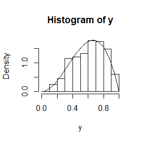

```r
hist(y,prob = TRUE)#histogram of the sample
z <- seq(0, 1, 0.01)
lines(z, 12*z*z*(1-z))#the theoretical Beta(3,2) density superimposed
```

# exercise 3.12

# answer

```r
n <- 1000
r <- 4
beta <- 2
lambda <- rgamma(n, r, beta) #Gamma(r,??) distribution
x <- rexp(n, lambda)#Exp(??) distribution
x
```

[output not shown]

[output cut: 185 more lines]

# 2

# question

### exercise 5.4

Write a function to compute a Monto Carlo estimate of the Beta(3,3) cdf,and use the function to estimate F(x) for x=0.1,0.2,…,0.9.Compare the estimates with the values returned by the pbeta function in R.

# answer

First,we can write the Beta(3,3) cdf.
$$\int_{0}^{x}30t^2(1-t)^2 dt$$
So,we get the Monto Carlo estimate is :

```r
MCF<-function(a){
  m<-1e4
  t<-runif(m,0,a)# get the uniform sample
  theta.hat <- mean(30*a*t^2*(1-t)^2)# get the Monto Carlo estimate
  print(theta.hat)
}
pv<-c(0.1,0.2,0.3,0.4,0.5,0.6,0.7,0.8,0.9)
for(x in pv){
 print(x)
 MCF(x)
 print(pbeta(x,3,3))#use the pbeta function and compare with MCF
}
```

```
## [1] 0.1
## [1] 0.008653314
## [1] 0.00856
## [1] 0.2
## [1] 0.05802282
## [1] 0.05792
## [1] 0.3
## [1] 0.1662394
## [1] 0.16308
## [1] 0.4
## [1] 0.3144435
## [1] 0.31744
## [1] 0.5
## [1] 0.4980498
## [1] 0.5
## [1] 0.6
## [1] 0.6766138
## [1] 0.68256
## [1] 0.7
## [1] 0.8310249
## [1] 0.83692
## [1] 0.8
## [1] 0.9388361
## [1] 0.94208
## [1] 0.9
## [1] 0.9851631
## [1] 0.99144
```

# question

### exercise 5.9

The Rayleigh density [156, (18.76)] is
$$f(x)=\frac{x}{\sigma^2}e^\frac{-x^2}{2\sigma^2}\quad x>=0, \sigma>0.$$

Implement a function to generate samples from a Rayleigh(??) distribution.using antithetic variables. What is the percent reduction in variance of $\frac{X+X'}{2}$ compared with $\frac{X1+X2}{2}$ for independent X1, X2?

# answer

We can get Rayleigh(??) distribution by the Rayleigh density.That is
$$F(x)=1-e^\frac{-x^2}{2\sigma^2}\quad x>=0, \sigma>0.$$
So,we can get the inverse function is
$$G(x)=\sqrt{-2\sigma^2ln(1-x)}\quad X=U(0,1).$$
by using antithetic variables,we can get samples from the Rayleigh(??) distribution.
$$\frac{X+X'}{2}=\frac{\sqrt{-2\sigma^2ln(1-x)}+\sqrt{-2\sigma^2ln(x)}}{2}\quad X=U(0,1).$$

```r
m<-1e4
x<-runif(m,0,1)
a<-(sqrt(-2*log(1-x))+sqrt(-2*log(x)))/2
b<-sqrt(-2*log(1-x))
c(var(a),var(b),var(b)/var(a))#compare the results
```

```
## [1]  0.01211678  0.43873936 36.20923948
```

# question

### exercise 5.13

Find two importance functions f1 and f2 that are supported on (1,??) and are ??close?? to
$$g(x)=\frac{x^2}{\sqrt{2\pi}}e^\frac{-x^2}{2}\quad x>1.$$
Which of your two importance functions should produce the smaller variance in estimating
$$\int_{1}^{??}\frac{x^2}{\sqrt{2\pi}}e^\frac{-x^2}{2}dx$$
by importance sampling? Explain.

# answer

We can get two importance functions f1 and f2
$$f1(x)=\frac{1}{x^2}\quad x>1.$$
$$f2(x)=xe^\frac{1-x^2}{2}\quad x>1.$$
So,we can get the cdf
$$F1(x)=1-\frac{1}{x}\quad x>1.$$
$$F2(x)=1-e^\frac{1-x^2}{2}\quad x>1.$$
So,we can get the inverse function
$$H1(x)=\frac{1}{1-x}\quad X=U(0,1).$$
$$H2(x)=\sqrt{1-2ln(1-x)}\quad X=U(0,1).$$

```r
m<-1e4
x<-runif(m,0,1)
a<-1/(1-x)
b<-sqrt(1-2*log(1-x))
theta1<-sum(a^4*exp(-a^2/2))/sqrt(2*pi)/m#get the mean
theta2<-sum(b/sqrt(2*pi*exp(1)))/m
print(c(theta1,theta2))
```

```
## [1] 0.4061032 0.3991410
```

```r
var1<-var(a^4*exp(-a^2/2)/sqrt(2*pi))#get the variance
var2<-var(b/sqrt(2*pi*exp(1)))
print(c(var1,var2))
```

```
## [1] 0.09258629 0.01467898
```

So we can find the same mean,but f2 has the smaller variance. That is,f2 is the better importance function.

# question

### exercise 5.14

Obtain a Monte Carlo estimate of
$$\int_{1}^{??}\frac{x^2}{\sqrt{2\pi}}e^\frac{-x^2}{2}dx$$
by importance sampling.

# answer

We can get the importance functions f
$$f(x)=xe^\frac{1-x^2}{2}\quad x>1.$$
So,we can get the cdf
$$F(x)=1-e^\frac{1-x^2}{2}\quad x>1.$$
So,we can get the inverse function
$$H(x)=\sqrt{1-2ln(1-x)}\quad X=U(0,1).$$
So,
$$g(x)/f(x)=\frac{x}{\sqrt{2e\pi}}\quad x>1.$$

```r
m<-1e4
x<-runif(m,0,1)
b<-sqrt(1-2*log(1-x))
theta<-sum(b/sqrt(2*pi*exp(1)))/m#get the mean
print(theta)
```

```
## [1] 0.3992236
```

```r
var2<-var(b/sqrt(2*pi*exp(1)))#get the variance
print(var2)
```

```
## [1] 0.01477193
```

# 3

# Question

### exercise 6.9

Let X be a non-negative random variable with $\mu=E\rvert{x}\rvert < ??$. For a random sample x1,…,xn from the distribution of X, the Gini ratio is defined by
$$G=\frac{1}{2n^2\mu}\sum_{j=1}^{n}\sum_{i=1}^{n}\rvert{x_i-x_j}\rvert$$
The Gini ratio is applied in economics to measure inequality in income distribution (see e.g. [163]). Note that G can be written in terms of the order statistics $x_(i) as
$$G=\frac{1}{n^2\mu}\sum_{i=1}^{n}(2i-n-1)x_{(i)}$$
If the mean is unknown,let $\widehat{G}$ be the statistic G with ?? replaced by $\overline{x}$. Estimate by simulation the mean, median and deciles of $\widehat{G}$ if X is standard lognormal. Repeat the procedure for the uniform distribution and Bernoulli(0.1). Also construct density histograms of the replicates in each case.

# Answer

```r
m<-1e3
n<-100
G.hat<-numeric(m)
for(i in 1:m){
  x<-rlnorm(n)#X is standard lognormal
  mu<-mean(x)
  sum0<-0
  for(j in 1:n){
    for(k in 1:n){
      sum0<-sum0+abs(x[j]-x[k])
    }
  }
  G.hat[i]<-sum0/(2*n^2*mu)
}
print(c(G.mean=mean(G.hat),G.median=median(G.hat),G.deciles=quantile(G.hat,c(0.1,0.9))))
```

```
##        G.mean      G.median G.deciles.10% G.deciles.90%
##     0.5130236     0.5090968     0.4634670     0.5671024
```

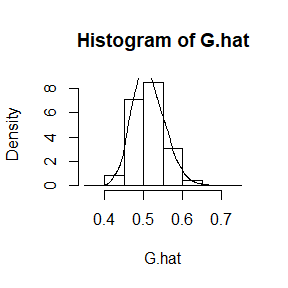

```r
hist(G.hat,freq = FALSE)
lines(density(G.hat))
```

```r
m<-1e3
n<-10
G.hat<-numeric(m)
for(i in 1:m){
  x<-runif(n)#uniform distribution
  mu<-mean(x)
  sum0<-0
  for(j in 1:n){
    for(k in 1:n){
      sum0<-sum0+abs(x[j]-x[k])
    }
  }
  G.hat[i]<-sum0/(2*n^2*mu)
}
print(c(G.mean=mean(G.hat),G.median=median(G.hat),G.deciles=quantile(G.hat,c(0.1,0.9))))
```

```
##        G.mean      G.median G.deciles.10% G.deciles.90%
##     0.3095617     0.3059000     0.2113061     0.4070990
```

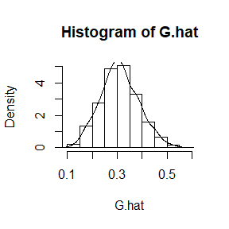

```r
hist(G.hat,freq = FALSE)
lines(density(G.hat))
```

```r
m<-1e3
n<-10
G.hat<-numeric(m)
for(i in 1:m){
  x<-rbinom(n,m,0.1)#Bernoulli(0.1)
  mu<-mean(x)
  sum0<-0
  for(j in 1:n){
    for(k in 1:n){
      sum0<-sum0+abs(x[j]-x[k])
    }
  }
  G.hat[i]<-sum0/(2*n^2*mu)
}
print(c(G.mean=mean(G.hat),G.median=median(G.hat),G.deciles=quantile(G.hat,c(0.1,0.9))))
```

```
##        G.mean      G.median G.deciles.10% G.deciles.90%
##    0.04822970    0.04750618    0.03333333    0.06369396
```

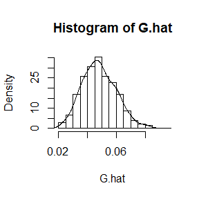

```r
hist(G.hat,freq = FALSE)
lines(density(G.hat))
```

### exercise 6.10

Construct an approximate 95% confidence interval for the Gini ratio $\gamma=E[G]$ if X is lognormal with unknown parameters. Assess the coverage rate of the estimation procedure with a Monte Carlo experiment.

# Answer

```r
n<-50
m<-100
k<-200
G1<-numeric(m)
Grlnorm<-function(n){
  x<-rlnorm(n)
  mu<-mean(x)
  sum0<-0
  for(j in 1:n){
    for(k in 1:n){
      sum0<-sum0+abs(x[j]-x[k])
    }
  }
  return(sum0/(2*n^2*mu))
}
for(i in 1:m){
  G1[i]<-Grlnorm(n)
}
gamma.mean<-mean(G1)
gamma.sd<-sd(G1)
a<-gamma.mean-qt(0.95,df=m-1)*gamma.sd/sqrt(m)
b<-gamma.mean+qt(0.95,df=m-1)*gamma.sd/sqrt(m)#confidence interval(a,b)
gamma1<-numeric(k)
for(i in 1:k){
  G2<-numeric(m)
  for(j in 1:m){
    G2[j]<-Grlnorm(n)
  }
  gamma1[i]<-mean(G2)
}
cat('The confidence interval of gamma is (',round(a,4),',',round(b,4),'),and the coverage rate is ',round(sum(gamma1>a&gamma1<b)/k,3)*100,'%',sep = '')
```

```
## The confidence interval of gamma is (0.4867,0.5054),and the coverage rate is 58%
```

### exercise 6.B

# Answer

```r
library(MASS)
n<-100
m<-1000
pearson.p<-numeric(m)
kendall.p<-numeric(m)
spearman.p<-numeric(m)

sigma0<-matrix(c(1,0.2,0.2,1),ncol = 2)#bivariate normal
mu<-c(0,1)
for(i in 1:m){
  mlnorm<-mvrnorm(n,mu,sigma0)
  x<-mlnorm[,1]
  y<-mlnorm[,2]
  pearson<-cor.test(x,y,method = 'pearson')
  kendall<-cor.test(x,y,method = 'kendall')
  spearman<-cor.test(x,y,method = 'spearman')
  pearson.p[i]<-pearson$p.value
  kendall.p[i]<-kendall$p.value
  spearman.p[i]<-spearman$p.value
}
cat('pearson:',sum(pearson.p<0.05)/m,
    'kendall:',sum(kendall.p<0.05)/m,
    'spearman:',sum(spearman.p<0.05)/m)#reject the null hypothesis
```

```
## pearson: 0.533 kendall: 0.474 spearman: 0.482
```

```r
library(MASS)
n<-100
m<-1000
pearson.p<-numeric(m)
kendall.p<-numeric(m)
spearman.p<-numeric(m)

sigma0<-matrix(c(1,0,0,1),ncol = 2)#X and Y are dependent
mu<-c(0,1)
for(i in 1:m){
  mlnorm<-mvrnorm(n,mu,sigma0)
  x<-mlnorm[,1]
  y<-mlnorm[,2]
  pearson<-cor.test(x,y,method = 'pearson')
  kendall<-cor.test(x,y,method = 'kendall')
  spearman<-cor.test(x,y,method = 'spearman')
  pearson.p[i]<-pearson$p.value
  kendall.p[i]<-kendall$p.value
  spearman.p[i]<-spearman$p.value
}
cat('pearson:',sum(pearson.p<0.05)/m,
    'kendall:',sum(kendall.p<0.05)/m,
    'spearman:',sum(spearman.p<0.05)/m)#accept the null hypothesis
```

```
## pearson: 0.052 kendall: 0.048 spearman: 0.046
```

# 4

# Question

### Exercise 7.1

Compute a jackknife estimate of the bias and the standard error of the correlation statistic in Example 7.2.

# Answer

```r
library(bootstrap)
n<-nrow(law)    #sample size
theta.jack<-numeric(n) #storage for replicates
b.cor<-function(x,i) cor(x[i,1],x[i,2])
theta.hat<-b.cor(law,1:n)
for(i in 1:n){
  theta.jack[i]<-b.cor(law,(1:n)[-i])
}
bias.jack<-(n-1)*(mean(theta.jack)-theta.hat)
se.jack<-sqrt((n-1)*mean((theta.jack-theta.hat)^2))
round(c(original=theta.hat,bias=bias.jack, se=se.jack),3)
```

```
## original     bias       se
##    0.776   -0.006    0.143
```

# 5

# Question

### Exercise 7.1

Compute a jackknife estimate of the bias and the standard error of the correlation statistic in Example 7.2.

# Answer

```r
library(bootstrap)
n<-nrow(law)    #sample size
theta.jack<-numeric(n) #storage for replicates
b.cor<-function(x,i) cor(x[i,1],x[i,2])
theta.hat<-b.cor(law,1:n)
for(i in 1:n){
  theta.jack[i]<-b.cor(law,(1:n)[-i])
}
bias.jack<-(n-1)*(mean(theta.jack)-theta.hat)
se.jack<-sqrt((n-1)*mean((theta.jack-theta.hat)^2))
round(c(original=theta.hat,bias=bias.jack, se=se.jack),3)
```

```
## original     bias       se
##    0.776   -0.006    0.143
```

### Exercise 7.4

Refer to Exercise 7.4. Compute 95% bootstrap confidence intervals for the mean time between failures 1/?? by the standard normal, basic, percentile, and BCa methods. Compare the intervals and explain why they may di???er.

# Answer

```r
library(boot)
set.seed(1)
n<-nrow(aircondit) #sample size
mean(aircondit[,1])
```

```
## [1] 108.0833
```

```r
boot.mean<-function(x,i) mean(x[i,1]) #give the mean function
boot.out<-boot(data=aircondit,statistic=boot.mean,R=1000)
boot.ci(boot.out,conf=0.95)
```

```
## BOOTSTRAP CONFIDENCE INTERVAL CALCULATIONS
## Based on 1000 bootstrap replicates
##
## CALL :
## boot.ci(boot.out = boot.out, conf = 0.95)
##
## Intervals :
## Level      Normal              Basic
## 95%   ( 31.7, 181.8 )   ( 25.8, 170.9 )
##
## Level     Percentile            BCa
## 95%   ( 45.3, 190.4 )   ( 53.3, 214.6 )
## Calculations and Intervals on Original Scale
## Some BCa intervals may be unstable
```

we can find 95% bootstrap confidence intervals are different,because we use different test types.

### Exercise 7.8

Refer to Exercise 7.7. Obtain the jackknife estimates of bias and standard error of $\hat{\theta}$.

# Answer

```r
library(bootstrap)
n<-nrow(scor)
theta.jack<-numeric(n)
n<-nrow(scor)
theta.jack<-numeric(n)
scor.pr<-function(x,i){
  a<-eigen(cor(x[i,]))
  a$values[1]/sum(a$values) # the proportion of variance
}
theta.hat<-scor.pr(scor,1:n)
for(j in 1:n){
  theta.jack[j]<-scor.pr(scor,(1:n)[-j])
}
bias.jack<-(n-1)*(mean(theta.jack)-theta.hat)
se.jack<-sqrt((n-1)*mean((theta.jack-theta.hat)^2))
round(c(original=theta.hat,bias=bias.jack, se=se.jack),3)
```

```
## original     bias       se
##    0.636    0.000    0.045
```

### Exercise 7.11

In Example 7.18, leave-one-out (n-fold) cross validation was used to select the best fitting model. Use leave-two-out cross validation to compare the models.

# Answer

```r
library(DAAG)
attach(ironslag)
n <- length(magnetic) #in DAAG ironslag
e1 <- e2 <- e3 <- e4 <- numeric((n-1)*n) #the size of samples
k=1
for(i in 1:(n-1)){
  for(j in (i+1):n){
  y<- magnetic[-i][-(j-1)]
  x<- chemical[-i][-(j-1)] #leave-two-out samples


  J1 <- lm(y ~ x)
  yhat1 <- J1$coef[1] + J1$coef[2] * chemical[i]
  e1[k] <- magnetic[i] - yhat1  #check out the modle

  J2 <- lm(y ~ x + I(x^2))
  yhat2 <- J2$coef[1] + J2$coef[2] * chemical[i] + J2$coef[3] * chemical[i]^2
  e2[k] <- magnetic[i] - yhat2

  J3 <- lm(log(y) ~ x)
  logyhat3 <- J3$coef[1] + J3$coef[2] * chemical[i]
  yhat3 <- exp(logyhat3)
  e3[k] <- magnetic[i] - yhat3

  J4 <- lm(log(y) ~ log(x))
  logyhat4 <- J4$coef[1] + J4$coef[2] * log(chemical[i])
  yhat4 <- exp(logyhat4)
  e4[k] <- magnetic[i] - yhat4

  k<-k+1

  yhat1 <- J1$coef[1] + J1$coef[2] * chemical[j]
  e1[k] <- magnetic[j] - yhat1

  yhat2 <- J2$coef[1] + J2$coef[2] * chemical[j] + J2$coef[3] * chemical[j]^2
  e2[k] <- magnetic[j] - yhat2

  logyhat3 <- J3$coef[1] + J3$coef[2] * chemical[j]
  yhat3 <- exp(logyhat3)
  e3[k] <- magnetic[j] - yhat3

  logyhat4 <- J4$coef[1] + J4$coef[2] * log(chemical[j])
  yhat4 <- exp(logyhat4)
  e4[k] <- magnetic[j] - yhat4

  k<-k+1

  }
}
c(mean(e1^2), mean(e2^2), mean(e3^2), mean(e4^2)) #get the square error
```

```
## [1] 19.57227 17.87018 18.45491 20.46718
```

```r
lm(formula = magnetic ~ chemical + I(chemical^2))
```

```
##
## Call:
## lm(formula = magnetic ~ chemical + I(chemical^2))
##
## Coefficients:
##   (Intercept)       chemical  I(chemical^2)
##      24.49262       -1.39334        0.05452
```

According to the prediction error criterion, Model 2, the quadratic model, would be the best fit for the data. The fitted regression equation for Model 2 is
$$\hat{Y}=24.49262-1.39334X+0.05452X^2$$

Compare with the leave-one-out (n-fold) cross validation,the leave-two-out cross validation has same conclusion,but more complicated,more accurate.

# 6

# Question

### exercise 8.1

Implement the two-sample Cramer-von Mises test for equal distributions as a permutation test. Apply the test to the data in Examples 8.1 and 8.2.

# Answer

```r
set.seed(1)
attach(chickwts)
x <- sort(as.vector(weight[feed == "soybean"]))
y <- sort(as.vector(weight[feed == "linseed"]))
detach(chickwts)
n<-length(x)
m<-length(y)
R<-999 #repeat
z<-c(x,y)
h<-1:26
reps<-numeric(R)
cvm<-function(a,b){
  F<-ecdf(a)
  G<-ecdf(b)
  m*n*(sum((F(a)-G(a))^2)+sum((F(b)-G(b))^2))/((m+n)^2)
}
w0<-cvm(x,y)
for (i in 1:R) {
  k <- sample(h, size = n, replace = FALSE)
  x1 <- z[k]
  y1 <- z[-k]
  reps[i] <-cvm(x1,y1)
}#permutation test
p <- mean(abs(c(w0, reps)) >= abs(w0))
round(p,3)
```

```
## [1] 0.421
```

because p=0.421>0.05,so we can not reject.

### exercise

Design experiments for evaluating the performance of the NN, energy, and ball methods in various situations.

Unequal variances and equal expectations

we can change the parameter to solve the problem.

# Answer

we can change the mu

```r
library(Ball)
library(energy)
library(boot)
library(RANN)
m <- 1e3
k<-3
p<-2
mu <- 0.5
set.seed(12345)
n1 <- n2 <- 20
R<-999
n <- n1+n2
N = c(n1,n2)
eqdist.nn <- function(z,sizes,k){
  boot.obj <- boot(data=z,statistic=Tn,R=R, sim = "permutation", sizes = sizes,k=k)
  ts <- c(boot.obj$t0,boot.obj$t)
  p.value <- mean(ts>=ts[1])
  list(statistic=ts[1],p.value=p.value)
}
p.values <- matrix(NA,m,3)
Tn <- function(z, ix, sizes,k){
  n1 <- sizes[1]
  n2 <- sizes[2]
  n <- n1 + n2
  if(is.vector(z))
    z <- data.frame(z,0);
  z <- z[ix, ]
  NN <- nn2(data=z, k=k+1)
  block1 <- NN$nn.idx[1:n1,-1]
  block2 <- NN$nn.idx[(n1+1):n,-1]
  i1 <- sum(block1 < n1 + .5)
  i2 <- sum(block2 > n1+.5)
  (i1 + i2) / (k * n)
}
for(i in 1:m){
  x <- matrix(rnorm(n1*p),ncol=p);
  y <- cbind(rnorm(n2),rnorm(n2,mean=mu));
  z <- rbind(x,y)
  p.values[i,1] <- eqdist.nn(z,N,k)$p.value
  p.values[i,2] <- eqdist.etest(z,sizes=N,R=R)$p.value
  p.values[i,3] <- bd.test(x=x,y=y,R=999,seed=i*12345)$p.value
}#get p.values by the NN, energy, and ball methods.
alpha <- 0.1
pow <- colMeans(p.values<alpha)
round(pow,3)
```

```
## [1] 0.178 0.374 0.300
```

Unequal variances and unequal expectations

# Answer

we can change the sd

```r
library(Ball)
library(energy)
library(boot)
library(RANN)
m <- 1e3
k<-3
p<-2
sd1<-2
set.seed(12345)
n1 <- n2 <- 20
R<-999
n <- n1+n2
N = c(n1,n2)
eqdist.nn <- function(z,sizes,k){
  boot.obj <- boot(data=z,statistic=Tn,R=R, sim = "permutation", sizes = sizes,k=k)
  ts <- c(boot.obj$t0,boot.obj$t)
  p.value <- mean(ts>=ts[1])
  list(statistic=ts[1],p.value=p.value)
}
p.values <- matrix(NA,m,3)
Tn <- function(z, ix, sizes,k){
  n1 <- sizes[1]
  n2 <- sizes[2]
  n <- n1 + n2
  if(is.vector(z))
    z <- data.frame(z,0)
  z <- z[ix, ]
  NN <- nn2(data=z, k=k+1)
  block1 <- NN$nn.idx[1:n1,-1]
  block2 <- NN$nn.idx[(n1+1):n,-1]
  i1 <- sum(block1 < n1 + .5)
  i2 <- sum(block2 > n1+.5)
  (i1 + i2) / (k * n)
}
for(i in 1:m){
  x <- matrix(rnorm(n1*p),ncol=p)
  y <- cbind(rnorm(n2),rnorm(n2,sd=sd1))
  z <- rbind(x,y)
  p.values[i,1] <- eqdist.nn(z,N,k)$p.value
  p.values[i,2] <- eqdist.etest(z,sizes=N,R=R)$p.value
  p.values[i,3] <- bd.test(x=x,y=y,R=999,seed=i*12345)$p.value
}
alpha <- 0.1
pow <- colMeans(p.values<alpha)
round(pow,3)
```

```
## [1] 0.384 0.363 0.633
```

Non-normal distributions: t distribution with 1 df (heavy-tailed distribution), bimodel distribution (mixture of two normal distributions)

# Answer

we can change the df

```r
library(Ball)
library(energy)
library(boot)
library(RANN)
m <- 1e3
df<-1
df2<-2
k<-3
p<-2
set.seed(12345)
n1 <- n2 <- 20
R<-999
n <- n1+n2
N = c(n1,n2)
eqdist.nn <- function(z,sizes,k){
  boot.obj <- boot(data=z,statistic=Tn,R=R, sim = "permutation", sizes = sizes,k=k)
  ts <- c(boot.obj$t0,boot.obj$t)
  p.value <- mean(ts>=ts[1])
  list(statistic=ts[1],p.value=p.value)
}
p.values <- matrix(NA,m,3)
Tn <- function(z, ix, sizes,k){
  n1 <- sizes[1]
  n2 <- sizes[2]
  n <- n1 + n2
  if(is.vector(z))
    z <- data.frame(z,0)
  z <- z[ix, ]
  NN <- nn2(data=z, k=k+1)
  block1 <- NN$nn.idx[1:n1,-1]
  block2 <- NN$nn.idx[(n1+1):n,-1]
  i1 <- sum(block1 < n1 + .5)
  i2 <- sum(block2 > n1+.5)
  (i1 + i2) / (k * n)
}
for(i in 1:m){
  x <- matrix(rt(n1*p,df=df),ncol=p)
  y <- cbind(rt(n2,df=df),rt(n2,df=df2))
  z <- rbind(x,y)
  p.values[i,1] <- eqdist.nn(z,N,k)$p.value
  p.values[i,2] <- eqdist.etest(z,sizes=N,R=R)$p.value
  p.values[i,3] <- bd.test(x=x,y=y,R=999,seed=i*12345)$p.value
}
alpha <- 0.1
pow <- colMeans(p.values<alpha)
round(pow,3)
```

```
## [1] 0.108 0.133 0.162
```

```r
library(Ball)
library(energy)
library(boot)
library(RANN)
m <- 1e3
t<-0.8
k<-3
p<-2
set.seed(12345)
n1 <- n2 <- 20
R<-999
n <- n1+n2
N = c(n1,n2)
eqdist.nn <- function(z,sizes,k){
  boot.obj <- boot(data=z,statistic=Tn,R=R, sim = "permutation", sizes = sizes,k=k)
  ts <- c(boot.obj$t0,boot.obj$t)
  p.value <- mean(ts>=ts[1])
  list(statistic=ts[1],p.value=p.value)
}
p.values <- matrix(NA,m,3)
Tn <- function(z, ix, sizes,k){
  n1 <- sizes[1]
  n2 <- sizes[2]
  n <- n1 + n2
  if(is.vector(z))
    z <- data.frame(z,0)
  z <- z[ix, ]
  NN <- nn2(data=z, k=k+1)
  block1 <- NN$nn.idx[1:n1,-1]
  block2 <- NN$nn.idx[(n1+1):n,-1]
  i1 <- sum(block1 < n1 + .5)
  i2 <- sum(block2 > n1+.5)
  (i1 + i2) / (k * n)
}
for(i in 1:m){
  x <- matrix(rbinom(n1*p,1,0.5),ncol=p)
  y <- cbind(rbinom(n2,1,0.5),rbinom(n2,1,t))
  z <- rbind(x,y)
  p.values[i,1] <- eqdist.nn(z,N,k)$p.value
  p.values[i,2] <- eqdist.etest(z,sizes=N,R=R)$p.value
  p.values[i,3] <- bd.test(x=x,y=y,R=999,seed=i*12345)$p.value
}
alpha <- 0.1
pow <- colMeans(p.values<alpha)
round(pow,3)
```

```
## [1] 0.361 0.518 0.458
```

Unbalanced samples

# Answer

we can change the n1,n2

```r
library(Ball)
library(energy)
library(boot)
library(RANN)
m <- 1e3
k<-3
p<-2
set.seed(12345)
n1<-20
n2<-30
R<-999
n <- n1+n2
N = c(n1,n2)
eqdist.nn <- function(z,sizes,k){
  boot.obj <- boot(data=z,statistic=Tn,R=R, sim = "permutation", sizes = sizes,k=k)
  ts <- c(boot.obj$t0,boot.obj$t)
  p.value <- mean(ts>=ts[1])
  list(statistic=ts[1],p.value=p.value)
}
p.values <- matrix(NA,m,3)
Tn <- function(z, ix, sizes,k){
  n1 <- sizes[1]
  n2 <- sizes[2]
  n <- n1 + n2
  if(is.vector(z))
    z <- data.frame(z,0);
  z <- z[ix, ]
  NN <- nn2(data=z, k=k+1)
  block1 <- NN$nn.idx[1:n1,-1]
  block2 <- NN$nn.idx[(n1+1):n,-1]
  i1 <- sum(block1 < n1 + .5)
  i2 <- sum(block2 > n1+.5)
  (i1 + i2) / (k * n)
}
for(i in 1:m){
  x <- matrix(rnorm(n1*p),ncol=p)
  y <- cbind(rnorm(n2),rnorm(n2))
  z <- rbind(x,y)
  p.values[i,1] <- eqdist.nn(z,N,k)$p.value
  p.values[i,2] <- eqdist.etest(z,sizes=N,R=R)$p.value
  p.values[i,3] <- bd.test(x=x,y=y,R=999,seed=i*12345)$p.value
}
alpha <- 0.1
pow <- colMeans(p.values<alpha)
round(pow,3)
```

```
## [1] 0.095 0.102 0.104
```

### exercise 9.3

Use the Metropolis-Hastings sampler to generate random variables from a standard Cauchy distribution. Discard the ???rst 1000 of the chain, and compare the deciles of the generated observations with the deciles of the standard Cauchy distribution(see qcauchy or qt with df=1). Recall that a Cauchy(??,??) distribution has density function
$$f(x)=\frac{1}{\theta\pi(1+[(x-\eta)/\theta]^2)}\quad ,\theta>0$$
The standard Cauchy has the Cauchy(?? =1,??= 0) density. (Note that the standard Cauchy density is equal to the Student t density with one degree of freedom.)

# Answer

```r
set.seed(1)

m<-20000 #length of the chain
x<-numeric(m)
y<-numeric(m-1000)
x[1]<-runif(1)

standard_cauchy<-function(x){
  return(1/(pi*(1+x^2)))
}

for(i in 1:(m-1)){
  proposal<-x[i]+runif(1,min=-1,max=1)
  accept<-runif(1)<=standard_cauchy(proposal)/standard_cauchy(x[i])
  x[i+1]<-ifelse(accept==T,proposal,x[i])
}

y<-x[1001:m]

quantile(y,probs = seq(0.1,0.9,0.1))
```

```
##         10%         20%         30%         40%         50%         60%
## -2.68474979 -1.22085681 -0.60227674 -0.22692955  0.09615792  0.45686422
##         70%         80%         90%
##  0.91602211  1.78290203  5.34850141
```

```r
qcauchy(seq(0.1,0.9,0.1))
```

```
## [1] -3.0776835 -1.3763819 -0.7265425 -0.3249197  0.0000000  0.3249197
## [7]  0.7265425  1.3763819  3.0776835
```

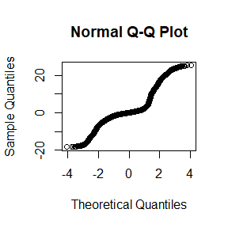

```r
qqnorm(y)
```

### exercise 9.6

Rao [220, Sec. 5g] presented an example on genetic linkage of 197 animals in four categories (also discussed in [67, 106, 171, 266]). The group sizes are(125,18,20,34). Assume that the probabilities of the corresponding multinomial distribution are
$$(\frac{1}{2}+\frac{\theta}{4},\frac{1-\theta}{4},\frac{1-\theta}{4},\frac{\theta}{4})$$
Estimate the posterior distribution of ?? given the observed sample, using one of the methods in this chapter.

# Answer

```r
set.seed(1)
m<-10000 #length of the chain
w<-0.25 #width
u<-runif(m)
v<-runif(m,-w,w)
group<-c(125,18,20,34)
x<-numeric(m)

prob<-function(theta){
  if(theta<0||theta>=0.8)
    return(0)
  else
    return((1/2+theta/4)^group[1]*((1-theta)/4)^group[2]*((1-theta)/4)^group[3]*(theta/4)^group[4])
}

x[1]<-0.3 #initial value
for(i in 2:m){
  theta<-x[i-1]+v[i]
  if(u[i]<=prob(theta)/prob(x[i-1]))
    x[i]<-theta
  else
    x[i]<-x[i-1]
}

theta.hat<-mean(x[1001:m])
print(theta.hat)
```

```
## [1] 0.6229572
```

# 7

# Question

### Exercise 9.6

For exercise 9.6, use the Gelman-Rubin method to monitor convergence of the chain, and run the chain until the chain has converged approximately to the target distribution according to $\hat{R}<1.2$.

# Answer

```
## [1] 0.1602727
```

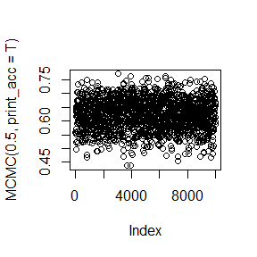

```r
b=1000
m=10000
N=b+m
Gelman.Rubin <- function(psi){
  # psi[i,j] is the statistic psi(X[i,1:j])
  # for chain in i-th row of X
  psi <- as.matrix(psi)
  n <- ncol(psi)
  k <- nrow(psi)
  psi.means <- rowMeans(psi) #row means
  B <- n * var(psi.means) #between variance est.
  psi.w <- apply(psi, 1, "var") #within variances
  W <- mean(psi.w) #within est.
  v.hat <- W*(n-1)/n + (B/(n*k)) #upper variance est.
  r.hat <- v.hat / W #G-R statistic return(r.hat)
}
iden<-function(theta){
  125*log(2+theta)+38*log(1-theta)+34*log(theta)
}
MCMC<-function(x,print_acc=F){
  y=1:N
  acc=0
  for(i in 1:N){
    p=runif(1)
    y[i]=x=if(runif(1)<exp(iden(p)-iden(x))){acc=acc+1;p}else x
  }
  if(print_acc) print(acc/N)
  y[(b+1):N]
}
plot(MCMC(0.5,print_acc = T))
```

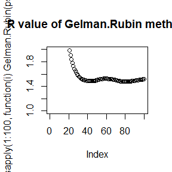

```r
M1=cumsum((MC1=MCMC(0.2)))/1:m
M2=cumsum((MC2=MCMC(0.4)))/1:m
M3=cumsum((MC3=MCMC(0.6)))/1:m
M4=cumsum((MC4=MCMC(0.8)))/1:m
psi=rbind(M1,M2,M3,M4)
plot((R=sapply(1:100,function(i)Gelman.Rubin(psi[,1:i]))),main="R value of Gelman.Rubin method",ylim=c(1,2))
```

```r
c(mean(c(MC1[1:10000],MC2[1:10000],MC3[1:10000],MC4[1:10000])),var(c(MC1[1:10000],MC2[1:10000],MC3[1:10000],MC4[1:10000])))
```

```
## [1] 0.623428767 0.002489491
```

### exercise 11.4

Find the intersection points A(k) in $(0,\sqrt{k})$of the curves
$$S_{k-1}(a)=P\big(t(k-1)>\sqrt{\frac{a^2(k-1)}{k-a^2}}\big)$$
and
$$S_{k}(a)=P\big(t(k)>\sqrt{\frac{a^2k}{k+1-a^2}}\big)$$
for k =4:25,100,500,1000, where t(k) is a Student t random variable with k degrees of freedom. (These intersection points determine the critical values for a t-test for scale-mixture errors proposed by Sz??ekely [260].)

```r
alpha<-rep(1,25)
b<-c(4:25,100,500,1000)
for(i in 1:25){
  k=b[i]
inter<-function(a){
  pt(sqrt(a*a*(k-1)/(k-a*a)),df=k-1,lower.tail=F,log.p=T)-pt(sqrt(a*a*k/(k+1-a*a)),df=k,lower.tail=F,log.p=T)
}
solution <- uniroot(inter,lower=0.0001,upper=sqrt(k)-0.0001)
alpha[i]<- solution$root
print(alpha[i])
}#intersection points
```

```
## [1] 1.49209
## [1] 1.533554
## [1] 1.562754
## [1] 1.584418
## [1] 1.60118
## [1] 1.614514
## [1] 1.625379
## [1] 1.634409
## [1] 1.642024
## [1] 1.64854
## [1] 1.654173
## [1] 1.659098
## [1] 1.663459
## [1] 1.667283
## [1] 1.670705
## [1] 1.673847
## [1] 1.676613
## [1] 1.679154
## [1] 1.681467
## [1] 1.683565
## [1] 1.685546
## [1] 1.687347
## [1] 1.720616
## [1] 1.729718
## [1] 1.730897
```

# 8

# 11.6

Write a function to compute the cdf of the Cauchy distribution, which has density
$$f(x)=\frac{1}{\theta\pi(1+[(x-\eta)/\theta]^2)}\quad -\infty<x<\infty$$
where $\theta$ > 0. Compare your results to the results from the R function pcauchy. (Also see the source code in pcauchy.c.)

```r
cdfCauchy = function(q, eta=0, theta=1) {
pdf = function(x,eta,theta){ 1/(theta*pi*(1 + ((x-eta)/theta)^2)) }
 result = integrate( f=pdf,
 lower=-Inf, upper=q,
 rel.tol=.Machine$double.eps^.25,
 eta=eta, theta=theta )
# return( list( value=result$value, abs.error=result$abs.error ) )
 return( result$value )
 } #end function
```

consider the standard Cauchy

```r
x = matrix( seq(-4,4), ncol=1 )
cbind( x, apply(x, MARGIN=1, FUN=cdfCauchy), pcauchy(x) )
```

```
##       [,1]       [,2]       [,3]
##  [1,]   -4 0.07797913 0.07797913
##  [2,]   -3 0.10241638 0.10241638
##  [3,]   -2 0.14758362 0.14758362
##  [4,]   -1 0.25000000 0.25000000
##  [5,]    0 0.50000000 0.50000000
##  [6,]    1 0.75000000 0.75000000
##  [7,]    2 0.85241638 0.85241638
##  [8,]    3 0.89758362 0.89758362
##  [9,]    4 0.92202087 0.92202087
```

for $\eta=2\quad and\quad\theta=1$:

```r
cbind( x, apply( x, MARGIN=1, FUN=cdfCauchy, eta=2 ),
 pcauchy(x,location=2) )
```

```
##       [,1]       [,2]       [,3]
##  [1,]   -4 0.05256846 0.05256846
##  [2,]   -3 0.06283296 0.06283296
##  [3,]   -2 0.07797913 0.07797913
##  [4,]   -1 0.10241638 0.10241638
##  [5,]    0 0.14758362 0.14758362
##  [6,]    1 0.25000000 0.25000000
##  [7,]    2 0.50000000 0.50000000
##  [8,]    3 0.75000000 0.75000000
##  [9,]    4 0.85241638 0.85241638
```

for $\eta=0\quad and\quad\theta=2$:

```r
cbind( x, apply( x, MARGIN=1, FUN=cdfCauchy, theta=2 ),
 pcauchy(x,scale=2) )
```

```
##       [,1]      [,2]      [,3]
##  [1,]   -4 0.1475836 0.1475836
##  [2,]   -3 0.1871670 0.1871670
##  [3,]   -2 0.2500000 0.2500000
##  [4,]   -1 0.3524164 0.3524164
##  [5,]    0 0.5000000 0.5000000
##  [6,]    1 0.6475836 0.6475836
##  [7,]    2 0.7500000 0.7500000
##  [8,]    3 0.8128330 0.8128330
##  [9,]    4 0.8524164 0.8524164
```

# A-B-O blood type problem

```r
library(stats4)
nA<-28;nB<-24;nOO<-41;nAB<-70;
n<-nA+nB+nOO+nAB;
i=0;
p1<-0.3;q1<-0.3;
p0<-0;q0<-0;
options(warn=-1)
while(!isTRUE(all.equal(p0,p1,tolerance=10^(-7)))||!isTRUE(all.equal(q0,q1,tolerance=10^(-7))))#EM?㷨
{
  p0<-p1;
  q0<-q1;
mlogL<-function(p,q){
  # minus log-likelihood
return(-(2*n*p0^2*log(p)+2*n*q0^2*log(q)+2*nOO*log(1-p-q)+(nA-n*p0^2)*log(2*p*(1-p-q))+(nB-n*q0^2)*(log(2*q*(1-p-q)))+nAB*log(2*p*q)))
}
fit<-mle(mlogL,start=list(p=0.2,q=0.3))
p1<-fit@coef[1]
q1<-fit@coef[2]
i=i+1
}
print(c(i,p1,q1))
```

```
##                     p          q
## 15.0000000  0.3685174  0.3493727
```

# 9

# Question

### Exercise 3

Use both for loops and lapply() to ???t linear models to the mtcars using the formulas stored in this list: formulas <- list( mpg ~ disp, mpg ~ I(1 / disp), mpg ~ disp + wt, mpg ~ I(1 / disp) + wt )

# Answer

```r
set.seed(1)
attach(mtcars)
formulas <- list(
mpg ~ disp,
mpg ~ I(1 / disp),
mpg ~ disp + wt,
mpg ~ I(1 / disp) + wt
)
n<-length(formulas)
# for loop
for(i in 1:n){
  print(lm(formulas[[i]]))
}
```

```
##
## Call:
## lm(formula = formulas[[i]])
##
## Coefficients:
## (Intercept)         disp
##    29.59985     -0.04122
##
##
## Call:
## lm(formula = formulas[[i]])
##
## Coefficients:
## (Intercept)    I(1/disp)
##       10.75      1557.67
##
##
## Call:
## lm(formula = formulas[[i]])
##
## Coefficients:
## (Intercept)         disp           wt
##    34.96055     -0.01772     -3.35083
##
##
## Call:
## lm(formula = formulas[[i]])
##
## Coefficients:
## (Intercept)    I(1/disp)           wt
##      19.024     1142.560       -1.798
```

```r
# lapply
lapply(formulas,lm)
```

```
## [[1]]
##
## Call:
## FUN(formula = X[[i]])
##
## Coefficients:
## (Intercept)         disp
##    29.59985     -0.04122
##
##
## [[2]]
##
## Call:
## FUN(formula = X[[i]])
##
## Coefficients:
## (Intercept)    I(1/disp)
##       10.75      1557.67
##
##
## [[3]]
##
## Call:
## FUN(formula = X[[i]])
##
## Coefficients:
## (Intercept)         disp           wt
##    34.96055     -0.01772     -3.35083
##
##
## [[4]]
##
## Call:
## FUN(formula = X[[i]])
##
## Coefficients:
## (Intercept)    I(1/disp)           wt
##      19.024     1142.560       -1.798
```

```r
#we can see the values are equal

detach(mtcars)
```

### Exercise 4

Fit the model mpg ~ disp to each of the bootstrap replicates of mtcars in the list below by using a for loop and lapply(). Can you do it without an anonymous function?

bootstraps <- lapply(1:10, function(i) { rows <- sample(1:nrow(mtcars), rep = TRUE) mtcars[rows, ] })

# Answer

```r
set.seed(1)
bootstraps <- lapply(1:10, function(i) {
rows <- sample(1:nrow(mtcars), rep = TRUE)
mtcars[rows, ]
})
# for loop
for(i in 1:10){
  print(lm(bootstraps[[i]]$mpg~bootstraps[[i]]$disp))
}
```

```
##
## Call:
## lm(formula = bootstraps[[i]]$mpg ~ bootstraps[[i]]$disp)
##
## Coefficients:
##          (Intercept)  bootstraps[[i]]$disp
##             28.05769              -0.03647
##
##
## Call:
## lm(formula = bootstraps[[i]]$mpg ~ bootstraps[[i]]$disp)
##
## Coefficients:
##          (Intercept)  bootstraps[[i]]$disp
##             29.11683              -0.04082
##
##
## Call:
## lm(formula = bootstraps[[i]]$mpg ~ bootstraps[[i]]$disp)
##
## Coefficients:
##          (Intercept)  bootstraps[[i]]$disp
##             26.57385              -0.02937
##
##
## Call:
## lm(formula = bootstraps[[i]]$mpg ~ bootstraps[[i]]$disp)
##
## Coefficients:
##          (Intercept)  bootstraps[[i]]$disp
##             28.28313              -0.03724
##
##
## Call:
## lm(formula = bootstraps[[i]]$mpg ~ bootstraps[[i]]$disp)
##
## Coefficients:
##          (Intercept)  bootstraps[[i]]$disp
##             31.60253              -0.04562
##
```

[output cut: 24 more lines]

```
##
## Call:
## lm(formula = bootstraps[[i]]$mpg ~ bootstraps[[i]]$disp)
##
## Coefficients:
##          (Intercept)  bootstraps[[i]]$disp
##             26.52186              -0.02975
##
##
## Call:
## lm(formula = bootstraps[[i]]$mpg ~ bootstraps[[i]]$disp)
##
## Coefficients:
##          (Intercept)  bootstraps[[i]]$disp
##             28.06815              -0.03533
```

```r
# lapply
for(i in 1:10){
  bootstraps[[i]]<-subset(bootstraps[[i]],select=c(mpg,disp))
}
lapply(bootstraps,lm)
```

```
## [[1]]
##
## Call:
## FUN(formula = X[[i]])
##
## Coefficients:
## (Intercept)         disp
##    28.05769     -0.03647
##
##
## [[2]]
##
## Call:
## FUN(formula = X[[i]])
##
## Coefficients:
## (Intercept)         disp
##    29.11683     -0.04082
##
##
## [[3]]
##
## Call:
## FUN(formula = X[[i]])
##
## Coefficients:
## (Intercept)         disp
##    26.57385     -0.02937
##
##
## [[4]]
##
## Call:
## FUN(formula = X[[i]])
##
## Coefficients:
## (Intercept)         disp
##    28.28313     -0.03724
##
##
```

[output cut: 43 more lines]

```
## FUN(formula = X[[i]])
##
## Coefficients:
## (Intercept)         disp
##    26.52186     -0.02975
##
##
## [[10]]
##
## Call:
## FUN(formula = X[[i]])
##
## Coefficients:
## (Intercept)         disp
##    28.06815     -0.03533
```

```r
#we can see the values are equal
```

### Exercise 5

For each model in the previous two exercises,extract $R^2$ using the function below.

rsq <- function(mod) summary(mod)$r.squared

# Answer

```r
# Exercise 3
set.seed(1)
attach(mtcars)
formulas <- list(
mpg ~ disp,
mpg ~ I(1 / disp),
mpg ~ disp + wt,
mpg ~ I(1 / disp) + wt
)
n<-length(formulas)
# for loop
for(i in 1:n){
  print(summary(lm(formulas[[i]]))$r.squared)
}
```

```
## [1] 0.7183433
## [1] 0.8596865
## [1] 0.7809306
## [1] 0.8838038
```

```r
# lapply
lapply(formulas,function(x){
  summary(lm(x))$r.squared
})
```

```
## [[1]]
## [1] 0.7183433
##
## [[2]]
## [1] 0.8596865
##
## [[3]]
## [1] 0.7809306
##
## [[4]]
## [1] 0.8838038
```

```r
#we can see the values are equal
detach(mtcars)

# Exercise 4
set.seed(1)
bootstraps <- lapply(1:10, function(i) {
rows <- sample(1:nrow(mtcars), rep = TRUE)
mtcars[rows, ]
})
# for loop
for(i in 1:10){
  print(summary(lm(bootstraps[[i]]$mpg~bootstraps[[i]]$disp))$r.squared)
}
```

```
## [1] 0.6606581
## [1] 0.8160798
## [1] 0.5806448
## [1] 0.7407087
## [1] 0.7589143
## [1] 0.6561107
## [1] 0.6021043
## [1] 0.6888394
## [1] 0.5989015
## [1] 0.723953
```

```r
# lapply
for(i in 1:10){
  bootstraps[[i]]<-subset(bootstraps[[i]],select=c(mpg,disp))
}
lapply(bootstraps,function(x){
  summary(lm(x))$r.squared
})
```

```
## [[1]]
## [1] 0.6606581
##
## [[2]]
## [1] 0.8160798
##
## [[3]]
## [1] 0.5806448
##
## [[4]]
## [1] 0.7407087
##
## [[5]]
## [1] 0.7589143
##
## [[6]]
## [1] 0.6561107
##
## [[7]]
## [1] 0.6021043
##
## [[8]]
## [1] 0.6888394
##
## [[9]]
## [1] 0.5989015
##
## [[10]]
## [1] 0.723953
```

```r
#we can see the values are equal
```

### Exercise 3

The following code simulates the performance of a t-test for non-normal data. Use sapply() and an anonymous function to extract the p-value from every trial.

trials <- replicate( 100, t.test(rpois(10, 10), rpois(7, 10)), simplify = FALSE )

Extra challenge: get rid of the anonymous function by using [[ directly

# Answer

```r
set.seed(1)
trials <- replicate( 100, t.test(rpois(10, 10), rpois(7, 10)), simplify = FALSE )
sapply(trials,function(x){
  return(x$p.value)
})
```

```
##   [1] 0.125949930 0.800930340 0.952855296 0.452959855 0.483083494
##   [6] 0.320611150 0.706780317 0.063119508 0.621092522 0.162276154
##  [11] 0.820427933 0.053095862 0.914712292 0.792200487 0.390189150
##  [16] 0.538640844 0.143988430 0.788393427 0.672267752 0.216269737
##  [21] 0.534646674 0.809214595 0.960266963 0.569466705 0.632178255
##  [26] 0.582700745 0.254983356 0.282179271 0.005098396 0.162075913
##  [31] 0.877783340 0.654074362 0.169752059 0.754440969 0.764179721
##  [36] 0.026793925 0.114713268 0.028496672 0.598991648 0.885239097
##  [41] 0.719211331 0.409696973 0.847167535 0.764438221 0.418863595
##  [46] 0.519132187 0.463910875 0.286785195 0.875030871 0.241068098
##  [51] 0.838739962 0.348638336 0.622633185 0.232606824 0.398974335
##  [56] 0.970218660 0.860375193 0.909101881 0.851096482 0.523397015
##  [61] 0.746860279 0.764894312 0.025411594 0.019036587 0.397989350
##  [66] 0.714919878 0.631471636 0.110724341 0.927143289 0.041990454
##  [71] 0.208117904 0.607178718 0.906974079 0.554576397 0.194404278
##  [76] 0.771678543 0.396686801 0.803958799 0.768941702 0.994186553
##  [81] 0.194123673 0.316046848 0.415575715 0.619270683 0.295629509
##  [86] 0.942948679 0.607585865 0.718018866 0.761453123 0.120281420
##  [91] 0.577128336 0.019315507 0.483007741 0.108496205 0.469918314
##  [96] 0.011282410 0.231024499 0.955230239 0.964944823 0.281065452
```

### Exercise 6

Implement a combination of Map() and vapply() to create an lapply() variant that iterates in parallel over all of its inputs and stores its outputs in a vector (or a matrix). What arguments should the function take?

# Answer

```r
library(foreach)
x<-foreach(a=1:3,b=rep(10,3),.combine = "rbind")%do%{
  x1<-(a+b)
  x2<-(a*b)
  c(x1,x2)
}
x
```

```
##          [,1] [,2]
## result.1   11   10
## result.2   12   20
## result.3   13   30
```

# 10

# Question

### exercise 4

### page 365, Advanced R

Make a faster version of chisq.test() that only computes the chi-square test statistic when the input is two numeric vectors with no missing values. You can try simplifying chisq.test() or by coding from the mathematical de???nition (http://en. wikipedia.org/wiki/Pearson%27s_chi-squared_test).

# Answer

```r
library(microbenchmark)
a=c(12,24)
b=c(25,10)
e=c(11,30)
f=c(40,34)
# chisq.test
tableR<-cbind(a,b)
chisq1=chisq.test(tableR)$statistic
# a faster version of chisq.test
chisq.test2<-function(x1,x2){
  x<-cbind(x1,x2)
  sr <- rowSums(x)
  sc <- colSums(x)
  n<-sum(sr)
  E <- outer(sr, sc, "*")/n
  YATES <- min(0.5, abs(x - E))
  STATISTIC <- sum((abs(x - E) - YATES)^2/E)
  return(STATISTIC)
}
chisq2=chisq.test2(a,b)
round(c(chisq1,chisq2),5)
```

```
## X-squared
##   8.85015   8.85015
```

```r
chisq1=chisq.test(cbind(e,f))$statistic
chisq2=chisq.test2(e,f)
round(c(chisq1,chisq2),5)
```

```
## X-squared
##   6.85835   6.85835
```

```r
# chisq2 is faster
ts <- microbenchmark(chisq1=chisq.test(tableR)$statistic,chisq2=chisq.test2(a,b))
summary(ts)[,c(1,3,5,6)]
```

```
##     expr     lq median      uq
## 1 chisq1 64.771 65.799 67.3415
## 2 chisq2 21.077 23.646 24.1610
```

### exercise 5

### page 365, Advanced R

Can you make a faster version of table() for the case of an input of two integer vectors with no missing values? Can you use it to speed up your chi-square test?

# Answer

```r
library(microbenchmark)
a=c(0,1,2,1,1,0,0,1)
b=c(0,0,1,1,1,0,1,1)
# a faster version of table()
table2 <- function(x, y) {
  x_val <- unique(x)
  y_val <- unique(y)
  mat <- matrix(0L, length(x_val), length(y_val))
  for (i in seq_along(x)) {
    mat[which(x_val == x[[i]]), which(y_val == y[[i]])]<-mat[which(x_val == x[[i]]),which(y_val == y[[i]])] + 1L
  }
  dimnames <- list(x_val, y_val)
  names(dimnames) <- as.character(as.list(match.call())[-1])  # R has names for dimnames... :/
  tab <- array(mat, dim = dim(mat), dimnames = dimnames)
  class(tab) <- "table"
  tab
}
table(a,b)
```

```
##    b
## a   0 1
##   0 2 1
##   1 1 3
##   2 0 1
```

```r
table2(a,b)
```

```
##    b
## a   0 1
##   0 2 1
##   1 1 3
##   2 0 1
```

```r
identical(table(a,b),table2(a,b))
```

```
## [1] TRUE
```

```r
d=c(1,2,3,2,2,5,3,1)
f=c(1,2,3,5,2,2,2,3)
table(d,f)
```

```
##    f
## d   1 2 3 5
##   1 1 0 1 0
##   2 0 2 0 1
##   3 0 1 1 0
##   5 0 1 0 0
```

```r
table2(d,f)
```

```
##    f
## d   1 2 3 5
##   1 1 0 1 0
##   2 0 2 0 1
##   3 0 1 1 0
##   5 0 1 0 0
```

```r
identical(table(d,f),table2(d,f))
```

```
## [1] TRUE
```

```r
# table2 is faster
ts <- microbenchmark(table=table(d,f),table2=table2(d,f))
summary(ts)[,c(1,3,5,6)]
```

```
##     expr       lq  median      uq
## 1  table 145.4770 149.590 151.646
## 2 table2  50.1205  53.462  55.518
```